# quarto-input6a01559e18a7069d – Home

#### W6: Frame Theory

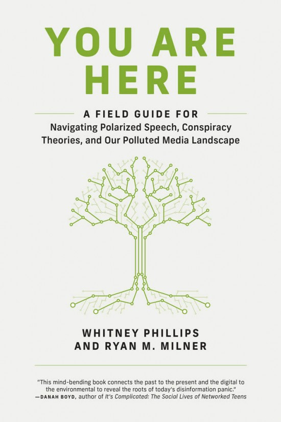

ch. 5: “Cultivating Ecological Literacy”  
ch. 6: “Choose Your Own Ethics Adventure”

In today’s discussion of Whitney Phillips and Ryan Milner’s book *You Are Here*, I’d like to focus on what they refer to throughout the book, including in the chapters assigned for this week, as **deep memetic frames**, and the concept of framing in particular.

One criticism that can be made of the book is that it discusses the social mediascape, its problems, and possible solutions to these, in terms of the transmission model that I was talking about last week, and doesn’t have a theory of ideology, i.e. what most people understand as the “truth” and the value systems by which it’s distinguished from falsehood.

While it’s true that the term ideology is hardly mentioned throughout the book, the term “deep memetic frames” is used with a very similar meaning, in fact they define it in the Introduction as “ideological ways of seeing and being” and “drivers of belief and identity.”

I thought it might be interesting to think about this issue of frames and framing in relation to the encoding and decoding of memes in social mediascapes. The term frame itself has multiple meanings, bringing to mind the metaphor of a window frame that shapes how we see the world, both in terms of what it shows but also what it screens out from sight. However, there’s another, more specific meaning of the term: the frame of a pair of eyeglasses that provides a literal frame through which we see the world and thus works as a metaphor for the concept of ideology.

*The Pervert’s Guide to Ideology*

In *You Are Here*, by contrast, the idea of “deep memetic frames” also has to do with ideology, but kind of reverses the metaphor of *They Live* in that the “frames” in this case correspond to the eyeglasses frames, that act as a kind of filter for the way things actually are, i.e. the world as it really/truly is. This idea of mimetic “frames” as a kind of ideological filter that shapes how we see the world is a useful idea, but in this case, the important point is that *everbody* is viewing the world through different memetic frames—everybody is wearing their own kind of memetic frames, but *without realizing that they are wearing them*, and thinking that they are just seeing the world as it really/truly is. This is the key aspect of ideology: paradoxically, it’s precisely what seems most “natural” or “normal,” what we take for granted as self-evidently true.

As an example, think about, say, veganism, and specifically how veganism is talked about by meat eaters, who may see it as “ideological”. After all, the meat eaters say, human beings have been carnivores since their earliest history, ergo eating meat is just the “natural” thing to do. What the meat eaters don’t see is that this position is itself ideological—for example, there’s no cultural reason why behaving like ancient neanderthals is more “natural” than preferring not to do so, since we now live in a completely different cultural world.

Anyway, to come back to the idea of “deep memetic frames,” what Phillips and Milner are clearly referring to here is ideological values and beliefs. The key word **memetic** here suggests two key things:

(i) whether we recognize it or not, all memes are *inherently ideological* in that they encode and express the system of ideas and values of the people who create or spread them; and as a corollary,

(ii) in internet culture, at least, ideological communication takes place primarily *through the circulation and exchange of memes*, which collectively frame our understandings of cultural, social, and political reality.

The problem of the social mediascape thus has to do with the proliferation of heterogeneous and/or incompatible “deep memetic frames” (i.e. ideologies)—the ideological eyeglasses through which everyone thinks they see the way things “really” are. How can I persuade you that your memetic frame is wrong? There’s no simple answer to this, but the notion of deep memetic frames at least enables us to see why people often seem so impervious to fact-checking and rational arguments.

I’m not trying to make a relativistic argument here, i.e. that all deep memetic frames are just “different perspectives” that are as valid as one another. What I’m saying, though, is that we have to see differences between, say, the worldviews of enlightenment liberalism and the conspiracy theories of Q’Anon not as being about “truth” but about incompatible systems of values (aka ideologies). This is why I agree with Phillips and Milner’s argument that the media response to Trump’s racist tweets about the four female politicians missed the point by trying to prove the legitimacy of their citizenship. It’s the same problem as people trying to factually disprove the claims that Barack Obama was not a U.S. citizen: even by treating the claim as something serious enough to merit being factually disproved, you’ve already lost the battle.

I hope some of the above will be helpful in thinking about the complex issues explored in You Are Here. And of course, I’m particularly interested to hear your thoughts on chapter six, and Phillips and Milner’s proposals for detoxing the polluted information landscape.